# Capitulo 12 - Estadistica 2

CAPITULO 12

Pruebas de bondad de ajuste e independencia

CONTENIDO

12.1 **PRUEBA DE BONDAD DE AJUSTE: UNA POBLACIÓN MULTINOMIAL**

12.2 **PRUEBA DE INDEPENDENCIA**

12.3 **PRUEBA DE BONDAD DE AJUSTE: DISTRIBUCIONES DE POISSON Y NORMAL**

- Distribución de Poisson
- Distribución normal

## 12.1 **Prueba de bondad de ajuste: una población multinomial**

En esta sección se estudia el caso en que cada elemento de una población corresponde a una y sólo a una de varias clases o categorías. A una población como esta se le denomina **población multinomial**, la cual se puede entender como una extensión de la distribución binomial al caso en el que hay tres o más categorías de resultados. En cada ensayo de un experimento multinomial, uno y sólo uno de los resultados ocurre. Se supone que cada ensayo es independiente y que en todos ellos las probabilidades para los resultados permanecen constantes.

Como ejemplo, durante las primeras 13 semanas de la temporada de televisión en Bolivia se registraron las proporciones siguientes de audiencia los sábados de 8:00 p.m. a 9:00 p.m.: Red Bolisión 29%, Unitel 28%, Red Uno 25% e independientes 18%.

En este caso la población de interés es multinomial y cada espectador se clasifica como televidentes de la cadena de televisión Bolivisión, Unitel, Red Uno o de los independientes. De manera que tenemos una población multinomial con cuatro resultados. Para las proporciones se usa la siguiente notación.

$$P_{A} = \text{ Horas de audiencia de la cadena de televisón Red Bolivisión}$$ $$P_{B} = \text{ Horas de audiencia de la cadena de televisón Unitel}$$ $$P_{C} = \text{ Horas de audiencia de la cadena de televisón Red Uno}$$ $$P_{D} = \text{ Horas de audiencia de la cadena de televisón independientes}$$

Se realizará un estudio muestral y calculará la proporción poblacional de la audiencia que prefiere ver una cadena de televisión. Después aplicará una prueba de hipótesis para ver para ver si en la temporada de televisión vario la audiencia de televidentes. Suponga que el producto no altera dicha participación; entonces, las hipótesis nula y alternativa serán las siguientes:

$$H_{0}: p_{A}= 0.29; p_{B} = 0.28, p_{C}=0.25 \text{ y } p_{D}=0.18$$ $$H_{a}: \text{ las proporciones poblacionales no son}$$ $$p_{A}= 0.29; p_{B} = 0.28, p_{C}=0.25 \text{ y } p_{D}=0.18$$

Considere que para este estudio en una muestra de 300 hogares se obtuvieron las audiencias siguientes en sábado por la noche: Bolivisión 95 hogares, Unitel 70, Red Uno 89, e independientes 46 hogares.

|  | Frecuencia observada |  |  |
| --- | --- | --- | --- |
| Bolivisión | Unitel | Red Uno | Independientes |
| 95 | 70 | 89 | 46 |

Ahora se realiza **la prueba de bondad de ajuste** para determinar si la muestra de las 300 preferencias de la audiencia coincide con la hipótesis nula. La prueba de bondad de ajuste se basa en la comparación de los resultados muestrales **observados** con los resultados **esperados** bajo el supuesto de que la hipótesis nula es verdadera. Por tanto, el paso siguiente es calcular las preferencias esperadas en las 300 audiencias asumiendo que $p_{A}= 0.29$; $p_{B} = 0.28$, $p_{C}=0.25$ y $p_{D}=0.18$. Al hacerlo, se tendrán los resultados esperados.

|  | Frecuencia esperada |  |  |
| --- | --- | --- | --- |
| Bolivisión | Unitel | Red Uno | Independientes |
| 300(0.29) = 87 | 300(0.28) = 84 | 300(0.25) = 75 | 300(0.18) = 54 |

Como se observa, la frecuencia esperada de cada categoría se encuentra al multiplicar el tamaño de la muestra, 300, por la proporción hipotética de esa categoría.

En la prueba de bondad de ajuste lo que interesa son las diferencias entre frecuencias observadas y esperadas. Grandes diferencias entre estas frecuencias harán dudar sobre el supuesto de que las proporciones o participación de mercado hipotética son correctas.

El siguiente estadístico de prueba ayuda a responder la pregunta de si las diferencias entre las frecuencias observadas y esperadas son “grandes” o “pequeñas”.

ESTADÍSTICO DE PRUEBA PARA LA BONDAD DE AJUSTE

$$ \chi^{2}=\displaystyle\sum^{k}_{i=1}\frac{(f_{i}-e_{i})^{2}}{e_{i}}(12.1) $$

donde: $$ f_{i} = \text{ frecuencia observada en la categoría } i $$ $$ e_{i} = \text{frecuencia esperada en la categoría } i $$ $$ k = \text{número de categorías.}$$ *Nota.* El estadístico de prueba tiene una distribución ji-cuadrada con $ k-1 $ grados de libertad, siempre que en todas las categorías las frecuencias esperadas sean 5 *o más*.

La hipótesis nula es rechazada si las diferencias entre las frecuencias observadas y esperadas son **grandes**. Estas diferencias darán un valor grande del estadístico de prueba. Entonces, la prueba de bondad de ajuste será siempre una prueba de cola superior. El área en la cola superior se emplea en el estadístico de prueba y en el método del **valor-p** para determinar si se puede rechazar la hipótesis nula. Para $k - 1 = 4 - 1 = 3$ grados de libertad, la tabla de ji-cuadrada (tabla 3 del apéndice B) proporciona lo siguiente.

| Área en la cola superior | 0.10 | 0.05 | 0.025 | 0.01 | 0.005 |
| --- | --- | --- | --- | --- | --- |
| **Valor $\chi^{2} $**(3 gl) | 6.251 | 7.815 | 9.348 | 11.345 | 12.838 |
| $ \chi^{2}= 6.87$ |  |  |  |  |  |

**Tabla 12.1** Cálculo del estadístico de prueba ji-cuadrada

| Categoría | Proporción hipotética | Frecuencia observada $(f_{i})$ | Frecuencia esperada $ (e_{i}) $ | Diferencia $ (f_{i}-e_{i}) $ | Cuadrado de la diferencia $ (f_{i}-e_{i})^{2} $ | Cuadrado de la diferencia dividido entre la frecuencia esperada $ (f_{i}-e_{i})^{2}/e_{i} $ |
| --- | --- | --- | --- | --- | --- | --- |
| **Bolivisión** | 0.29 | 95 | 87 | 8 | 64 | 0.74 |
| **Unitel** | 0.28 | 70 | 84 | -14 | 196 | 2.33 |
| **Red Uno** | 0.25 | 89 | 75 | 14 | 196 | 2.61 |
| **Independientes** | 0.18 | 46 | 54 | -8 | 64 | 1.19 |
| **Total** |  | 300 |  |  |  | $\chi^{2}=6.87$ |

Se realizó el cálculo de lo que se muestra en la tabla, en código en **Python**, usando la librería **scipy.stats**. De esta manera, es más fácil calcular el estadístico de prueba de la prueba chi-cuadrada y obtener el valor-p.

```python
import scipy.stats as stats
import numpy as np

#Se da los valores de la proporcion hipotetica y la frecuencia observada
p_hipotetica=np.array([0.29, 0.28, 0.25, 0.18])
observado = np.array([95, 70, 89, 46])

#Se calcula la frecuencia esperada con la proporcion hipotetica y la suma total de la frecuencia
#observada
suma=sum(observado)
esperado = suma*p_hipotetica

# Realiza la prueba de bondad de ajuste de chi-cuadrado
result = stats.chisquare(f_obs=observado, f_exp=esperado)

# Imprime el estadístico y el valor p
print(f"Estadístico de chi-cuadrado: {result.statistic:.2f}")
print(f"Valor-p: {result.pvalue:.4f}")
```

```
Estadístico de chi-cuadrado: 6.87
Valor-p: 0.0762
```

En la tabla ya mostrada, también se realizó un cálculo en código Python. Sin embargo, en este caso, se respeta el formato de resolución que se indica en la tabla.

```python
import scipy.stats as stats
from scipy.stats import chi2
import numpy as np

#Aca se va anotando los dos vectores de la proporcion hipotetica y de la frecuencia observada
proporcion_hipotetica = np.array([0.29, 0.28, 0.25, 0.18])
frecuencia_observada = np.array([95, 70, 89, 46])

#Se calcula aca la suma total de la frecuencia observada y se halla la frecuencia esperada
suma_f_o= sum(frecuencia_observada)
frecuencia_esperada = suma_f_o  * proporcion_hipotetica

#Ahora hallamos la diferencia, su cuadrado y luego de eso lo dividimos por su frec. esperada
diferencia = frecuencia_observada - frecuencia_esperada
diferencia_2 = diferencia**2
dividir_dif_2 = diferencia_2/frecuencia_esperada
estadistico_chi2 = sum(dividir_dif_2)
print(f"Estadístico de chi-cuadrado: {estadistico_chi2:.2f}")

#Ahora hallamos el valor-p
grados_de_libertad = len(frecuencia_observada)-1
p_valor = chi2.sf(estadistico_chi2, grados_de_libertad)
print(f"Valor-p: {p_valor:.4f}")
```

```
Estadístico de chi-cuadrado: 6.87
Valor-p: 0.0762
```

En lugar del método del $valor-p$ se puede utilizar el método del valor crítico, con el que se llega a la misma conclusión. Como $\alpha = 0.05 $ y los grados de libertad son 3, el valor crítico para el estadístico de prueba es $\chi^{2}_{0.05} = 7.814$. La regla de rechazo de la cola superior se convierte en  
Rechazar $H_{0}$ si $\chi^{2} \geq 7.814$

Como 6.87 < 7.814, no se rechaza $H_0$. Con los métodos del **valor crítico** o del **valor-p** se llega a la misma conclusión.

A continuación se presentan, en forma resumida, los pasos generales que se siguen en una prueba de bondad de ajuste para una distribución poblacional multinomial hipotética.

DISTRIBUCIÓN MULTINOMIAL DE PRUEBAS DE BONDAD DE AJUSTE: RESUMEN 1. Establecer las hipótesis nula y alternativa:

$$H_0: \text{ la población tiene una distribución multinomial con la}\\ \text{ probabilidad específica de cada una de las } k \text{ categorías}$$ $$H_a: \text{ la población no tiene una distribución multinomial con la}\\ \text{ probabilidad específica de cada una de las } k \text{ categorías}$$

2. Seleccionar una muestra aleatoria y anotar las frecuencias observadas $f_i$ en cada categoría.
3. Suponer que la hipótesis nula es verdadera y determinar la frecuencia esperada $e_i$ en cada categoría multiplicando la probabilidad de esa categoría por el tamaño de la muestra.
4. Calcular el valor del estadístico de prueba.
   $$\chi^{2}=\displaystyle\sum^{k}_{i=1}\frac{(f_{i}-e_{i})^{2}}{e_{i}}$$
5. Regla de rechazo:
   $$\text{Método del valor-p: Rechazar } H_0 \text{ si el valor-p}\leq \alpha$$ $$\text{Método del valor crítico: Rechazar} H_0 \text{ si } \chi^{2}\geq \chi^{2}_{\alpha}$$ donde $\alpha$ es el nivel de significancia utilizado para la prueba y se tienen $k - 1$ grados de libertad.

[video not shown]

## 12.2 **Prueba de independencia**

Otra aplicación importante de la distribución ji-cuadrada implica el uso de datos muestrales para probar la independencia de dos variables. Para ilustrar la prueba de independencia se considerará el siguiente ejercicio. Cuatro grupos de edad: 18-24, 25-34, 35-44, 45 y más. Al analizar el rango de edad de los cuatro grupos, el grupo de investigación de Visa Card, se preguntó si la inclinación de los consumidores categorizados en grupos de edad difería entre la forma de pago plástico y cheque o efectivo. En caso de que las preferencias fueran independientes de la forma de pago del consumidor, se iniciaría una campaña publicitaria para el uso de las tarjetas de crédito o débito. Pero si las preferencias por la forma de pago dependían del grupo de edad, Visa Card ajustaría sus promociones a los diferentes mercados meta.

Se usó una prueba de independencia para determinar si la preferencia por el grupo de edad (18-24, 25-34, 35-44, 45 y más) era independiente de la forma de pago (plástico, efectivo o cheque). Las hipótesis fueron las siguientes. $$H_0: \text{la preferencia por el grupo de edad es independiente de la forma de pago}$$ $$H_a: \text{la preferencia por el grupo de edad no es independiente de la forma de pago}$$

Para describir la situación a estudiar se usa la tabla 12.2. Después de identificar la población como todos los del grupo de edad en su forma de paga, plástico y efectivo o cheque, se toma una muestra y a cada individuo se le pide que indique cuál es su método de paga favorito. Cada sujeto de la muestra se clasificará en una de las ocho celdas de la tabla. Así, por ejemplo, se puede tener la forma de paga plástico que prefiera el grupo de edad 25-34 [celda (1,2)], o que se quiera pagar en efectivo o cheque por el grupo de edad 18-24 [celda (2,1)], o en la forma de paga sea efectivo o cheque sea preferida por el grupo de edad 35-44 [celda (2,3)], y así sucesivamente.

**TABLA 12.2** Tabla de contingencia de grupo de edad y la forma de pago del consumidor

[output not shown]

**TABLA 12.3** Resultados muestrales del tipo de grupo de edad y su forma de pago preferida plástico y efectivo o cheques (frecuencias observadas).

|  |  | Grupo de edad |  |  |  |
| --- | --- | --- | --- | --- | --- |
| Forma de pago | 18-24 | 25-34 | 35-44 | 45 y más | Total |
| **Plástico** | 21 | 27 | 27 | 36 | 111 |
| **Efectivo o cheque** | 21 | 36 | 42 | 90 | 189 |
| **Total** | 42 | 63 | 69 | 126 | 300 |

Dado que en la tabla se han enumerado todas las posibles combinaciones de grupos de edad y forma de pago o, en otras palabras, todas las posibles contingencias, a la tabla 12.2 se le llama tabla de contingencia. Como en la prueba de independencia se usa el formato de este tipo de tabla, a esta prueba también se le suele llamar prueba de **tabla de contingencia**. Como en la prueba de independencia se usa el formato de este tipo de tabla, a esta prueba también se le suele llamar **prueba de tabla de contingencia**.  
Suponga que toma una muestra aleatoria simple de 300 consumidores. Cada individuo de la muestra prueba los cuatro grupos de edad y después se le pide que indique cuál prefiere o cuál es su primera elección. En la tabulación cruzada de la tabla 12.3 se presenta el resumen de las respuestas recabadas en el estudio. Como se ve, los datos para la prueba de independencia se obtienen contando las cantidades o frecuencias correspondientes a cada celda o categoría. De las 300 personas de la muestra, 21 enla forma de pago plástico lo prefirieron los del grupo de edad 18-24, 27 el grupo de edad 25-34, 27 los del grupo 35-44, etcétera.

Los datos de la tabla 12.3 son las frecuencias observadas para cada una de las ocho clases o categorías. Si se determinan las frecuencias esperadas bajo el supuesto de independencia entre grupo de edad y forma de pago del consumidor, se puede emplear la distribución ji-cuadrada para establecer si existe diferencia significativa entre las frecuencias observadas y las esperadas.  
Las frecuencias esperadas para las celdas de la tabla de contingencia se basan en la idea siguiente. Primero se supone que la hipótesis nula es verdadera; es decir, que el grupo de edad es independiente de la forma de pago del consumidor. Después se observa que en la muestra de 300 consumidores, 42 son del grupo de edad 18-24, 63 del grupo 25-34 , 69 del grupo 35-44 y 126 del grupo 45 y más. En términos de proporciones se concluye que $ 42/300 = 7/50 $ de los consumidores son del **grupo 18-24**; $ 63/300 = 21/100 $ grupo de **25-34**; $ 69/300 = 23/100 $ el **grupo 35-44**, y $ 126/300 = 21/50 $ del **grupo 45 y más**. Si el supuesto de independencia es correcto, estas proporciones serán las que se observen tanto entre las formas de pago plástico y efectivo o cheque.

Por consiguiente, bajo el supuesto de independencia, es de esperarse que en la muestra de 111 sujetos en la forma de pago plástico, $(7/50)111 = 15.54$ del **grupo 18-24**, $(21/100)111 = 23.31$ del **grupo 25-34**, $(23/100)111 = 25.53$ del **grupo 35-44** y $ (21/50)111 = 46.62$ del **grupo 45 y más**. Al aplicar las proporciones correspondientes a los 189 consumidores que prefieren pagar en efectivo o cheque, se obtienen las frecuencias esperadas que aparecen en la tabla 12.4.

**TABLA 12.4** Frecuencias esperadas si la preferencia por uno de los tipos de grupo de edad es independiente de la forma de pago del consumidor.

|  |  | Grupo de edad |  |  |  |
| --- | --- | --- | --- | --- | --- |
| Forma de pago | 18-24 | 25-34 | 35-44 | 45 y más | Total |
| **Plástico** | 15.54 | 23.31 | 25.53 | 46.62 | 111 |
| **Efectivo o cheque** | 26.46 | 39.69 | 43.47 | 79.38 | 189 |
| **Total** | 42.00 | 63.00 | 69.00 | 126.00 | 300 |

Sea $e_{ij}$ la frecuencia esperada en la $f_i$ la $i$, columna $j$ de la tabla de contingencia. Mediante dicha notación, ahora se reconsidera el cálculo de la frecuencia esperada correspondiente a los que pagan con plástico (fila $i = 1$) que prefieren los del grupo **25-34**(columna $j = 2$), es decir, la frecuencia esperada $e_{12}$. Siguiendo el argumento anterior para el cálculo de esta frecuencia, vemos que

$$e_{12}=(21/100)111=23.31$$

Esta expresión se formula de una manera ligeramente diferente como

$$e_{12}=(21/100)111 = (63/300)111= \frac{(111)(63)}{300}=23.31$$

Observe que en esta expresión, 111 es el número total de la forma de pago con plástico (total de la fila 1), 63 es la cantidad total de individuos que estan en el grupo **25-34** (total de la columna 2) y 300 es el tamaño total de la muestra. Vemos entonces que

$$e_{12}= \frac{\text{(total de la fila 1)(total de la columna 2)}}{\text{tamaño de la muestra}}$$

La generalización de esta expresión lleva a la fórmula siguiente para obtener las frecuencias esperadas en una tabla de contingencia para una prueba de independencia.

FRECUENCIAS ESPERADAS PARA TABLAS DE CONTINGENCIA BAJO EL SUPUESTO DE INDEPENDENCIA

$$e_{12}= \frac{\text{(total de la fila i)(total de la columna j)}}{\text{tamaño de la muestra}}(12.2)$$

Al aplicar esta fórmula para los que pagan con plástico que prefieren del **grupo de edad 35-44**, encontramos que la frecuencia esperada es $e_{13} = 111(69)/300 = 25.53$, como se ilustra en la tabla 12.4. Use la ecuación (12.2) para verificar las otras frecuencias esperadas que se presentan en esta tabla.  
El procedimiento de prueba para comparar las frecuencias esperadas de la tabla 12.4 con las frecuencias observadas de la tabla 12.3 es semejante a los cálculos para la prueba de bondad de ajuste de la sección 12.1. En concreto, el valor $\chi^2$ que se basa en las frecuencias observadas y esperadas se calcula como se indica a continuación.

ESTADÍSTICO DE PRUEBA PARA INDEPENDENCIA

$$\chi^{2} = \displaystyle \sum_{i}\sum_{j} \frac{(f_{ij}-e_{ij})^{2}}{e_{ij}}(12.3)$$

Donde:

$ f_{ij} = $ frecuencia observada en la categoría de la fila $ i $ y la columna $ j $ de la tabla de contingencia.  
$ e_{ij} = $ frecuencia esperada en la categoría de la fila $ i $ y la columna $ j $ de la tabla de contingencia, basada en el supuesto de independencia.

*Nota.* Si una tabla de contingencia tiene $ n $ filas y $ m $ columnas, el estadístico de prueba tiene una distribución ji-cuadrada con $ (n-1)(m-1)$ grados de libertada, siempre y cuando las frecuencias esperadas sean cinco o más en todas las categorías.

| Área en la cola superior | 0.10 | 0.05 | 0.025 | 0.01 | 0.005 |
| --- | --- | --- | --- | --- | --- |
| Valor $\chi^{2} $(3 gl) | 6.251 | 7.815 | 9.348 | 11.345 | 12.838 |
| $ \chi^{2}= 7.95$ |  |  |  |  |  |

**Tabla 12.5** Cálculo del estadístico de prueba ji-cuadrada para determinar el grupo de edad es independiente de la forma de pago del consumidor.

| Forma de pago | Grupo de edad | Frecuencia observada $(f_{ij})$ | Frecuencia esperada $ (e_{ij}) $ | Diferencia $ (f_{ij}-e_{ij}) $ | Cuadrado de la diferencia $ (f_{ij}-e_{ij})^{2} $ | Cuadrado de la diferencia dividido entre la frecuencia esperada $ (f_{ij}-e_{ij})^{2}/e_{ij} $ |
| --- | --- | --- | --- | --- | --- | --- |
| Plastico | 18-24 | 21 | 15.54 | 5.46 | 29.81 | 1.918 |
| Plastico | 25-34 | 27 | 23.31 | 3.69 | 13.62 | 0.584 |
| Plastico | 35-44 | 27 | 25.53 | 1.47 | 2.16 | 0.085 |
| Plastico | 45 y más | 36 | 46.62 | -10.62 | 112.78 | 2.419 |
| Efectivo | 18-24 | 21 | 26.46 | -5.46 | 29.81 | 1.127 |
| Efectivo | 25-34 | 36 | 39.69 | -3.69 | 13.62 | 0.343 |
| Efectivo | 35-44 | 42 | 43.47 | -1.47 | 2.16 | 0.05 |
| Efectivo | 45 y más | 90 | 79.38 | 10.62 | 112.78 | 1.421 |
|  | **Total** | 300 | 300.00 |  |  | $\chi^2 = 7.95$ |

Se realizará el calculo de la tabla mediante el código de programación **Phyton**, para hallar el estadístico de prueba o la $\chi^2$.

```python
import numpy as np
from scipy.stats import chi2_contingency
frecuencia_obs = np.array([[21, 27, 27, 36],[21, 36, 42, 90]])
chi2, p, dof, expected = chi2_contingency(frecuencia_obs)
print(f"El estadistico de prueba de chi-cuadrado es: {chi2:.2f}")
print(f"El valor-p: {p:.4f}")
print("Los grados de libertad de la prueba son:",dof)
print("La frecuencia esperada es: ")
for i in expected:
    for j in i:
        print(j,end="  ")
    print()
```

```
El estadistico de prueba de chi-cuadrado es: 7.95
El valor-p: 0.0471
Los grados de libertad de la prueba son: 3
La frecuencia esperada es:
15.54  23.31  25.53  46.62
26.46  39.69  43.47  79.38
```

Se volvera a hacer los calculos, respetando el procedimiento de la tabla.

```python
import scipy.stats as stats
from scipy.stats import chi2
import numpy as np

#Se da valores a la frecuencia observada
frecuencia_obs = np.array([[21, 27, 27, 36],[21, 36, 42, 90]])

#Se suma el total de la matriz
total = 0
for i in frecuencia_obs:
    total+=sum(i)

#Se calcula el tamanio de la filas y las columnas de
num_fila = len(frecuencia_obs)
num_columna = len(frecuencia_obs[0])

#Se suma el valor total de las filas i y las columnas j
suma_fila = [sum(i) for i in frecuencia_obs]
suma_columna = [sum(j) for j in zip(*frecuencia_obs)]

#Se calcula la frecuencia esperada
frecuencia_esp = []
for i in range(num_fila):
    fila = []
    for j in range(num_columna):
        valor = (suma_fila[i]*suma_columna[j])/total
        fila.append(valor)
    frecuencia_esp.append(fila)

#Se calcula la diferencia entre la frecuencia observada y la esperada
diferencia = frecuencia_obs - frecuencia_esp

#diferencia al cuadrado
dif_2 = diferencia**2
#aca lo redondeamos a 2 decimales
diferencia_2 = np.array([[round(i ,2) for i in j] for j in dif_2])

#cuadrado de la diferencia dividido por la frecuencia esperada
dif_2_div = diferencia_2/frecuencia_esp
#redondeamos a 3 decimales
dif_2_div = [[round(i ,3) for i in j] for j in dif_2_div]

#Se suma el total de la diferencia dividido por la frecuencia
estadistico_chi2 = 0
for i in dif_2_div:
    estadistico_chi2 += sum(i)

#se calcula los grados de libertad
grados_de_libertad = (num_fila-1)*(num_columna-1)

#calculamos el valor-p
p_valor = chi2.sf(estadistico_chi2, grados_de_libertad)

#imprimimos los valores del estadistico de prueba, el valor-p, los grados de libertad y
#la frecuencia esperada
print(f"Estadistico de prueba de chi-cuadrado: {estadistico_chi2:.2f}")
print(f"Valor-p: {p_valor:.4f}")
print("Los grados de libertad de la prueba son: ",grados_de_libertad)
print("La frecuencia esperada es: ")
for i in frecuencia_esp:
    for j in i:
        print(j, end=" ")
    print()
```

```
Estadistico de prueba de chi-cuadrado: 7.95
Valor-p: 0.0471
Los grados de libertad de la prueba son:  3
La frecuencia esperada es:
15.54 23.31 25.53 46.62
26.46 39.69 43.47 79.38
```

A continuación se resumen los pasos para una prueba de independencia de la tabla de contingencia.

PRUEBA DE INDEPENDENCIA: RESUMEN

1. Establecer las hipótesis nula y alternativa:

$$H_0: \text{ la variable de las columnas es independiente de la variable de las filas }$$ $$H_a: \text{ la variable de las columnas no es independiente de la variable de las filas }$$

2. Seleccionar una muestra aleatoria y anotar las frecuencias observadas en cada celda de la tabla de contingencia.
3. Utilizar la ecuación (12.2) para calcular la frecuencia esperada de cada celda.
4. Usar la ecuación (12.3) para determinar el valor del estadístico de prueba. $$\chi^{2} = \displaystyle \sum_{i}\sum_{j} \frac{(f_{ij}-e_{ij})^{2}}{e_{ij}}$$
5. Regla de rechazo:
   $$\text{Método del valor-p: Rechazar } H_0 \text{ si el valor-p}\leq \alpha$$ $$\text{Método del valor crítico: Rechazar} H_0 \text{ si } \chi^{2}\geq \chi^{2}_{\alpha}$$

donde $\alpha$ es el nivel de significancia, con $n$ filas y $m$ columnas que proporcionan $(n - l)(m - 1)$ grados de libertad.

[video not shown]

## 12.3 **Prueba de bondad de ajuste: distribuciones de Poisson y normal**

En la sección 12.1 se introdujo la prueba de bondad de ajuste para poblaciones multinomiales. En general, esta prueba puede usarse con cualquier distribución de probabilidad hipotética. En esta sección se ilustra su uso para el caso en que tenemos la hipótesis de que la población tiene una distribución de Poisson o una distribución normal. Como verá, en la prueba de bondad de ajuste y en el uso de la distribución ji-cuadrada se sigue el mismo procedimiento general aplicado para la prueba de bondad de ajuste de la sección 12.1.

### **Distribución de Poisson**

El uso de la prueba de bondad de ajuste se ilustra en el caso de una distribución poblacional que hipotéticamente tiene una distribución de Poisson. Considere, por ejemplo, las llegadas de los clientes al Dubek’s Food Market en Tallahassee, Florida. Debido a recientes problemas de personal, los gerentes solicitan los servicios de una firma de consultoría para que les ayude en la programación de los empleados de caja. Después de revisar el avance de las filas en las cajas, la fi rma de consultoría sugerirá un procedimiento para la programación de los empleados. Este procedimiento se basa en un análisis matemático de las fi las y sólo es aplicable si el número de clientes que llegan durante un determinado lapso sigue una distribución de Poisson. Por tanto, antes de poner en marcha el procedimiento de programación, habrá que recabar datos sobre las llegadas de los clientes y realizar una prueba estadística para ver si es razonable suponer que los arribos siguen una distribución de Poisson.

Las llegadas a la tienda se definen en términos de **cantidad de clientes** que entran en el establecimiento durante intervalos de 5 minutos. Por tanto, las hipótesis nula y alternativa que se indican enseguida son apropiadas para el estudio de Dubek’s Food Market

$$H_{0}: \text{el número de clientes que entra en la tienda durante intervalos de}\\ \text{5 minutos tiene una distribución de probabilidad de Poisson}$$ $$H_{a}: \text{el número de clientes que entra en la tienda durante intervalos de}\\ \text{5 minutos no tiene una distribución de probabilidad de Poisson}$$

Si una muestra de llegadas de clientes indica que no se puede rechazar H0, Dubeck’s procederá a poner en marcha el proceso de programación de la firma de consultoría. Pero si la muestra lleva a rechazar $H_0$, no se podrá suponer que los arribos siguen una distribución de Poisson y habrá que considerar otro procedimiento de programación. Para probar el supuesto de que las llegadas de los clientes en las mañanas de los días entre semana siguen una distribución de Poisson, un empleado de la tienda toma una muestra aleatoria de 128 intervalos de 5 minutos en las mañanas de tres semanas consecutivas. Durante cada uno de los intervalos de 5 minutos que forman la muestra, el empleado registra el número de llegadas de clientes. Para resumir los datos, determina el número de intervalos de 5 minutos en los que no hubo ninguna llegada, el número de intervalos de 5 minutos en los que se registró una, el número de intervalos de 5 minutos en los que hubo dos, y así sucesivamente. Estos datos se presentan en la tabla 12.6.

**TABLA 12.6** Frecuencias observadas en las llegadas de los clientes a Dubek’s en una muestra de 128 intervalos de 5 minutos.

| Número de clientes que llegan $(x)$ | Frecuencia observada |
| --- | --- |
| 0 | 2 |
| 1 | 8 |
| 2 | 10 |
| 3 | 12 |
| 4 | 18 |
| 5 | 22 |
| 6 | 22 |
| 7 | 16 |
| 8 | 12 |
| 9 | 6 |
| **Total** | 128 |

La tabla proporciona las frecuencias observadas en las 10 categorías. Ahora se usa la prueba de bondad de ajuste para determinar si la muestra de los 128 lapsos favorece la hipótesis relacionada con la distribución de Poisson. Para usar la prueba de bondad de ajuste se deben considerar las frecuencias esperadas para cada una de las 10 categorías, bajo el supuesto de que la distribución de las llegadas sigue dicha distribución. Es decir, si en realidad esto ocurre, es necesario calcular el número esperado de lapsos en los que llegarán cero clientes, un cliente, dos clientes, etcétera. La función de probabilidad de Poisson, que ya se presentó en el capítulo 5, es $$f(x)=\frac{\mu^{x}e^{-\mu}}{x!} (12.4)$$

En esta función, $\mu$ representa la media o el número esperado de clientes que llegan en lapsos de 5 minutos, x representa la variable aleatoria del número de arribos en un lapso de 5 minutos y $f(x)$ es la probabilidad de que $x$ clientes llegarán en un lapso de 5 minutos. Antes de usar la ecuación (12.4) para calcular las probabilidades de Poisson, se necesita una estimación de $\mu$, el número medio de llegadas de clientes en un lapso de 5 minutos. La media muestral de los datos de la tabla 12.6 proporciona esta estimación. Como se tienen 2 lapsos de 5 minutos en los que no llegó ningún cliente, 8 lapsos de 5 minutos en los que llegó un cliente, etc., el número total de clientes que llegan en los 128 lapsos de 5 minutos es $0(2)+ 1(8) +2(10)+ . . . +9(6) = 640$. Este total de arribos en los 128 lapsos de la muestra dan una media de llegadas de $\mu = 640/128 = 5$ clientes por periodos de 5 minutos. Con este valor como media para la distribución de Poisson, una estimación de la función de probabilidad de Poisson en el caso de Dubek’s Food Market es $$f(x)=\frac{5^{x}e^{-5}}{x!} (12.5)$$

Esta función de probabilidad puede evaluarse para distintos valores de x y determinar así la probabilidad que corresponde a las diferentes categorías de llegadas. En la tabla 12.7 se presentan tales probabilidades, las cuales se encuentran también en la tabla 7 del apéndice B. Por ejemplo, la probabilidad de que lleguen $0$ clientes en un lapso de cinco minutos es $f(0) = 0.0067$, la probabilidad del arribo de un cliente en un lapso de 5 minutos es $f(l) = 0.0337$, y así sucesivamente. Como se vio en la sección 12.1, la frecuencia esperada en cada una de las categorías se encuentra al multiplicar su probabilidad por el tamaño de la muestra. Por ejemplo, el número de lapsos de tiempo con 0 llegadas es $(0.0067)(128) = 0.86$; el número esperado de lapsos con 1 llegada es $(0.0337)(128) = 4.31$, y así sucesivamente.

**TABLA 12.7** Frecuencias esperadas en las llegadas de clientes a Dubek’s, suponiendo que sigan una distribución de Poisson con $\mu = 5$.

| Número de clientes que llegan $(x)$ | Probabilidad de Poisson $f(x)$ | Número esperado de lapsos de 5 minutos con $x$ llegadas,128 $f(x)$ |
| --- | --- | --- |
| 0 | 0.0067 | 0.86 |
| 1 | 0.0337 | 4.31 |
| 2 | 0.0842 | 10.78 |
| 3 | 0.1404 | 17.97 |
| 4 | 0.1755 | 22.46 |
| 5 | 0.1755 | 22.46 |
| 6 | 0.1462 | 18.71 |
| 7 | 0.1044 | 13.36 |
| 8 | 0.0653 | 8.36 |
| 9 | 0.0363 | 4.65 |
| 10 | 0.0318 | 4.07 |
|  |  | Total 128.00 |

```python
#tabla 12.7

import scipy.stats as stats
import numpy as np
from scipy.stats import poisson
from scipy.stats import chi2
# Frecuencias observadas
frecuencias = {
    0: 2,
    1: 8,
    2: 10,
    3: 12,
    4: 18,
    5: 22,
    6: 22,
    7: 16,
    8: 12,
    9: 6
}
total_frec_obs= sum(frecuencias.values())
# Calcula la tasa de llegada (mu) como el promedio ponderado
mu = sum(k * v for k, v in frecuencias.items()) / total_frec_obs

# Calcula las probabilidades de Poisson
probabilidades = {k: poisson.pmf(k, mu) for k in frecuencias.keys()}

#Se hara la prueba si la suma de las probabilidades de poisson llegan a uno
suma_prob_poisson = sum(probabilidades.values())
if(suma_prob_poisson!=1):
    probabilidades[list(probabilidades.keys())[-1]+1]=1-suma_prob_poisson
    frecuencias[list(frecuencias.keys())[-1]+1] = 0

#Ahora se hara el calculo de la tabla 12.7

#Probabilidad de Poisson
print(f"La tasa de llegada promedio (mu) es {mu}")
print("Las probabilidades de Poisson son:")
for k, p in probabilidades.items():
    print(f"{k}: {p:.4f}")

#Numero esperado de lapsos de 5 mins con x, llegadas 128f(x)
num_esp = list(probabilidades.values())
num_esp = np.array(num_esp)
numero_esp = total_frec_obs*num_esp
print("Numero esperado de lapsos de 5 mins con x ")
for i in numero_esp:
    print(f"{i:.2f}")
suma_total_num_esp=sum(numero_esp)
print("Total: ",suma_total_num_esp)
```

```
La tasa de llegada promedio (mu) es 5.0
Las probabilidades de Poisson son:
0: 0.0067
1: 0.0337
2: 0.0842
3: 0.1404
4: 0.1755
5: 0.1755
6: 0.1462
7: 0.1044
8: 0.0653
9: 0.0363
10: 0.0318
Numero esperado de lapsos de 5 mins con x
0.86
4.31
10.78
17.97
22.46
22.46
18.72
13.37
8.36
4.64
4.07
Total:  128.0
```

Antes de hacer los cálculos de ji-cuadrada habituales para comparar las frecuencias observadas y esperadas, hay que notar que en la tabla 12.7 hay cuatro categorías que tienen una frecuencia esperada menor que cinco. Esta condición incumple los requerimientos para el uso de la distribución ji-cuadrada. Sin embargo, las categorías con frecuencias esperadas menores de cinco no son una difi cultad, ya que se pueden combinar categorías adyacentes para satisfacer la condición de que la frecuencia esperada sea “por lo menos de cinco”. En particular, se combinan 0 y 1 en una sola categoría y también se combinan 9 y “10 o más” en otra categoría simple. De esta manera se satisface la regla de un mínimo de cinco como frecuencia esperada en cada categoría. En la tabla 12.8 se presentan las frecuencias observadas y las esperadas después de combinar categorías.

Como en la sección 12.1, la prueba de bondad de ajuste se centra en las diferencias entre frecuencias observadas y esperadas, $f_i = e_i$. Por tanto, para calcular el estadístico de prueba ji-cuadrada se usarán las frecuencias observadas y esperadas de la tabla 12.8. $$\chi^{2}=\displaystyle\sum^{k}_{i=1}\frac{(f_{i}-e_{i})^{2}}{e_{i}}$$

**TABLA 12.8** Frecuencias observadas y esperadas en las llegadas de clientes a Dubek’s, después de combinar categorías.

| Número de clientes que llegan $(x)$ | Frecuencia observada $f_i$ | Frecuencia esperada $e_i$ |
| --- | --- | --- |
| 0 o 1 | 10 | 5.17 |
| 2 | 10 | 10.78 |
| 3 | 12 | 17.97 |
| 4 | 18 | 22.46 |
| 5 | 22 | 22.46 |
| 6 | 22 | 18.72 |
| 7 | 16 | 13.37 |
| 8 | 12 | 8.36 |
| 9 o más | 6 | 8.72 |
|  | Total 128 | 128.00 |

```python
#tabla 12.8
# convertimos el diccionario a una lista
frec = list(frecuencias.values())
frec = np.array(frec)
frec_esperada = []
frec_observada = []
# se creara los vectores de frecuencias
i = 0
while i < len(numero_esp):
    aux = numero_esp[i]
    aux1 = frec[i]
    if aux < 5:
        if i == len(numero_esp) - 1:
            frec_esperada[-1] +=aux
            frec_observada[-1] +=aux1
        else:
            frec_esperada.append(aux + numero_esp[i + 1])
            frec_observada.append(aux1 + frec[i + 1])
            i += 1
    else:
        frec_esperada.append(aux)
        frec_observada.append(aux1)

    i+=1

#Se imprimiran las frecuencias observadas y esperadas
frec_observada = np.array(frec_observada)
print("Frecuencia observada: ")
for i in frec_observada:
    print(f"{i}")

frec_esperada = np.array(frec_esperada)
print("Frecuencia esperada: ")
for i in frec_esperada:
    print(f"{i:.2f}")
```

```
Frecuencia observada:
10
10
12
18
22
22
16
12
6
Frecuencia esperada:
5.17
10.78
17.97
22.46
22.46
18.72
13.37
8.36
8.72
```

**TABLA 12.9** Cálculo del estadístico de prueba ji-cuadrada para el estudio de Dubek’s Food Market.

| Número de clientes que llegan $(x)$ | Frecuencia observada $(f_{i})$ | Frecuencia esperada $ (e_{i}) $ | Diferencia $ (f_{i}-e_{i}) $ | Cuadrado de la diferencia $ (f_{i}-e_{i})^{2} $ | Cuadrado de la diferencia dividido entre la frecuencia esperada $ (f_{i}-e_{i})^{2}/e_{i} $ |
| --- | --- | --- | --- | --- | --- |
| 0 o 1 | 10 | 5.17 | 4.83 | 23.28 | 4.50 |
| 2 | 10 | 10.78 | -0.78 | 0.61 | 0.06 |
| 3 | 12 | 17.97 | -5.97 | 35.62 | 1.98 |
| 4 | 18 | 22.46 | -4.46 | 19.89 | 0.89 |
| 5 | 22 | 22.46 | -0.46 | 0.21 | 0.01 |
| 6 | 22 | 18.72 | 3.28 | 10.78 | 0.58 |
| 7 | 16 | 13.37 | 2.63 | 6.92 | 0.52 |
| 8 | 12 | 8.36 | 3.64 | 13.28 | 1.59 |
| 9 o más | 6 | 8.72 | -2.72 | 7.38 | 0.85 |
|  | Total 128 | 128.00 |  |  | $\chi^2 = 10.96$ |

```python
#Tabla 12.9
#Se calcula aca la suma total de la frecuencia observada y se halla la frecuencia esperada
suma_f_o= sum(frec_observada)
#Ahora hallamos la diferencia, su cuadrado y luego de eso lo dividimos por su frec. esperada
diferencia = frec_observada - frec_esperada
diferencia_2 = diferencia**2
dividir_dif_2 = diferencia_2/frec_esperada
estadistico_chi2 = sum(dividir_dif_2)
print(f"Estadístico de chi-cuadrado: {estadistico_chi2:.2f}")

#Ahora hallamos el valor-p
grados_de_libertad = len(frec_observada)-2
p_valor = chi2.sf(estadistico_chi2, grados_de_libertad)
print(f"Valor-p: {p_valor:.4f}")
```

```
Estadístico de chi-cuadrado: 10.96
Valor-p: 0.1403
```

En la tabla 12.9 se muestran los cálculos necesarios para obtener el valor del estadístico de prueba ji-cuadrada. El valor del estadístico de prueba es $\chi^2= 10.96$. En general, en una prueba de bondad de ajuste la distribución ji-cuadrada tiene $k - p - 1$ grados de libertad, donde $k$ es el número de categorías y $p$ es el número de parámetros poblacionales estimados a partir de los datos muestrales. Para la prueba de bondad de ajuste de la distribución de Poisson, la tabla 12.9 indica que $k = 9$ categorías. Como los datos muestrales se usaron para estimar la media de la distribución de Poisson, $p = 1$, por ende tenemos $k - p - 1 = k - 2 $grados de libertad. Como $k=9$, tenemos $9 - 2 = 7$ grados de libertad.

Suponga que en la prueba de la hipótesis nula de que la distribución de probabilidad de las llegadas de los clientes es una distribución de Poisson, se usa $0.05$ como nivel de significancia. Para probar esta hipótesis, es necesario determinar el valor-p para el estadístico de prueba $\chi^2 = 10.96$ hallando el área en la cola superior de la distribución ji-cuadrada con 7 grados de libertad. En la tabla 3 del apéndice B se encuentra que $\chi^2 = 10.96$ corresponde a un área en la cola superior mayor que 0.10. Por consiguiente, sabemos que el valor-p es mayor que 0.10. Con los procedimientos de Minitab y de Excel que se describen en el apéndice F se obtiene que el $valor-p = 0.1404$. Como el $valor-p > \alpha = 0.05$, no se puede rechazar $H_0$. En consecuencia, no se puede descartar el supuesto de que las llegadas de los clientes, en las mañanas entre semana, sigan una distribución de probabilidad de Poisson. De esta manera, los gerentes de Dubek’s pueden continuar con el procedimiento de programación para las mañanas de los días entre semana.

PRUEBA DE BONDAD DE AJUSTE PARA LA DISTRIBUCIÓN DE POISSON: RESUMEN

1. Establecer las hipótesis nula y alternativa:

$$H_0: \text{ la población tiene una distribución de Poisson }$$ $$H_a: \text{ la población no tiene una distribución de Poisson }$$

2. Tomar una muestra aleatoria y  
   a) Registrar la frecuencia observada $f_i$ para cada valor de la variable aleatoria de Poisson.  
   b) Calcular el número medio $\mu$ de las ocurrencias.
3. Calcular, para cada valor de la variable aleatoria de Poisson, la frecuencia esperada $e_i$ de ocurrencias. Multiplicar el tamaño de la muestra por la probabilidad de Poisson de ocurrencia para cada valor de la variable aleatoria de Poisson. Si para algún valor hay menos de cinco ocurrencias esperadas, combinar valores adyacentes y reducir el número de categorías tanto como sea necesario.
4. Determinar el valor del estadístico de prueba. $$\chi^{2}=\displaystyle\sum^{k}_{i=1}\frac{(f_{i}-e_{i})^{2}}{e_{i}}$$
5. Regla de rechazo: $$\text{Método del valor-p: Rechazar } H_0 \text{ si el valor-p}\leq \alpha$$ $$\text{Método del valor crítico: Rechazar} H_0 \text{ si } \chi^{2}\geq \chi^{2}_{\alpha}$$

donde $\alpha$ es el nivel de significancia y los grados de libertad son $k - 2$.

[video not shown]

### **Distribución normal**

La prueba de bondad de ajuste para la distribución normal también se basa en el uso de la distribución ji-cuadrada. Se sigue un procedimiento similar al aplicado para la distribución de Poisson. Las frecuencias observadas en las diversas categorías de los datos muestrales se comparan con las frecuencias esperadas, en particular cuando se supone que la población tiene una distribución normal. Como esta distribución es continua, es necesario modifi car la manera en que se defi nen las categorías y en que se calculan las frecuencias esperadas. La prueba de bondad de ajuste para una distribución normal se ilustrará con los datos de los exámenes presentados por las personas que solicitan empleo en Chemline, Inc. Estos datos se presentan en la tabla 12.10.  
Cada año Chemline contrata a cerca de 400 nuevos empleados para sus cuatro plantas en Estados Unidos. El director de personal se pregunta si la población de puntuaciones de los exámenes de los solicitantes tendrá una distribución normal. Si es así, esta distribución podría servir para evaluar las puntuaciones; es decir, podrían identifi carse fácilmente las que se ubican en el 20% superior, el 40% inferior, etc. Por tanto, se desea probar la hipótesis nula de que la población de las puntuaciones de estos exámenes tiene una distribución normal.  
Para empezar, se obtienen estimaciones de la media y la desviación estándar de la distribución normal que se considerará en la hipótesis nula, considerando los datos de la tabla 12.10. La media muestral $\bar{x}$ y la desviación estándar muestral s se usan como estimadores puntuales de la media y la desviación estándar de la distribución normal. Los cálculos son los siguientes.

**TABLA 12.10** Puntuaciones obtenidas en una muestra aleatoria de 50 solicitantes de empleo en la prueba de aptitudes de Chemline.

| 71 | 66 | 61 | 65 | 54 | 93 | 60 | 86 | 70 | 70 |
| --- | --- | --- | --- | --- | --- | --- | --- | --- | --- |
| 73 | 73 | 55 | 63 | 56 | 62 | 76 | 54 | 82 | 79 |
| 76 | 68 | 53 | 58 | 85 | 80 | 56 | 61 | 61 | 64 |
| 65 | 62 | 90 | 69 | 76 | 79 | 77 | 54 | 64 | 74 |
| 65 | 65 | 61 | 56 | 63 | 80 | 56 | 71 | 79 | 84 |

$$\bar{x}=\frac{\sum x_i}{n}=\frac{3421}{50}=68.42$$

$$s=\sqrt{\frac{\sum \left ( x_i -x\right )^2}{n-1}}=\sqrt{\frac{5310.10}{49}}=10.41$$

```python
import numpy as np
datos = [71, 66, 61, 65, 54, 93,
        60, 86, 70, 70, 73, 73 ,
        55, 63, 56, 62, 76, 54 ,
        82, 79, 76, 68, 53, 58 ,
        85, 80, 56, 61, 61, 64,
        65, 62, 90, 69, 76, 79,
        77, 54, 64, 74, 65, 65,
        61, 56, 63, 80, 56, 71,
        79, 84]
media_resultado = datos
media = sum(datos) / len(datos)
sum_cuadrados_diferencias = sum((x - media)**2 for x in datos)
desviacion_estandar = round((sum_cuadrados_diferencias / (len(datos) - 1))**0.5,2)
print(f"x̄: {media}")
print(f"s: {desviacion_estandar}")
```

```
x̄: 68.42
s: 10.41
```

Con estos valores se establecen las siguientes hipótesis acerca de la distribución de las puntuaciones del examen de los aspirantes. $$H_0: \text{la población de las puntuaciones del examen tiene una distribución normal,}\\ \text{ con una media de 68.42 y una desviación estándar de 10.41}$$ $$H_a: \text{la población de las puntuaciones del examen no tiene una distribución normal,}\\ \text{ con una media de 68.42 y una desviación estándar de 10.41.}$$ En la figura 12.2 se ilustra esta distribución normal hipotética.

**FIGURA 12.2** Distribución normal hipotética de las puntuaciones de los exámenes para los solicitantes de empleo en Chemline realizado en Python.

```python
import numpy as np
import matplotlib.pyplot as plt
from scipy.stats import norm

# Generar datos para la distribución normal
x = np.linspace(media - 3*desviacion_estandar, media + 3*desviacion_estandar, 1000)
y = norm.pdf(x, media, desviacion_estandar)

# Graficando la Distribución normal hipotética
plt.plot(x, y, color='lightgreen', label='Distribución Normal')
plt.fill_between(x, y, color='lightgreen', alpha=0.3)
plt.text(0.88, 0.72, r'$\sigma=10.41$', verticalalignment='top', horizontalalignment='right',
         transform=plt.gca().transAxes, fontsize=12)
plt.text(0.5093, 0.07, r'┴', verticalalignment='top', horizontalalignment='right',
         transform=plt.gca().transAxes, fontsize=12)
plt.xlabel('Media 68.42')
plt.ylabel('')
plt.xticks([])
plt.yticks([])
plt.grid(True)
plt.show()
```

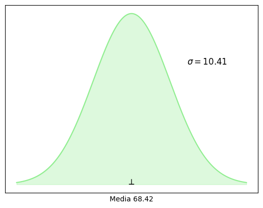

Ahora se verá cómo definir las categorías de una prueba de bondad de ajuste para una distribución normal. En el caso de la distribución de probabilidad discreta en la prueba para la distribución de Poisson fue fácil definir las categorías en términos del número de clientes que llegan, 0, 1, 2, etc. Sin embargo, para la distribución de probabilidad normal continua es necesario emplear un procedimiento diferente para definir las categorías, esto es, en términos de intervalos de puntuaciones de examen.  
Recuerde la regla de que en cada intervalo o categoría la frecuencia esperada debe ser por lo menos de cinco. Las categorías para las puntuaciones de examen se definen de manera que la frecuencia esperada en cada una sea por lo menos de cinco. Como el tamaño de la muestra es 50, una manera de establecer las categorías es dividir la distribución normal en 10 intervalos con una misma probabilidad (vea la figura 12.3). Dado que el tamaño de la muestra es 50, se espera tener cinco resultados en cada intervalo o categoría, con lo que se satisface la regla de las frecuencias esperadas.  
Veamos más de cerca el procedimiento para calcular los límites de las categorías. Como se trata de una distribución de probabilidad normal, para determinar estos límites se emplean las tablas de probabilidad normal estándar. Primero se determina la puntuación de examen que